# Determining the age of buyers by photo.

### Project description

The chain supermarket introduces a computer vision system for processing customer photos. Photo fixation in the checkout area will help determine the age of customers in order to: Analyze purchases and offer products that may be of interest to buyers of this age group; Control the conscientiousness of cashiers when selling alcohol. Build a model that will determine the approximate age of a person from a photo. At your disposal is a set of photographs of people with age indication.

### Project instructions

Conduct an exploratory analysis of a set of photographs.

Prepare data for training.

Train the neural network and calculate its quality.

## Exploratory data analysis.

```python
# < Перенесите сюда исследовательский анализ данных >
import pandas as pd
from tensorflow.keras.preprocessing.image import ImageDataGenerator
import matplotlib.pyplot as plt


labels = pd.read_csv('/datasets/faces/labels.csv')
train_datagen = ImageDataGenerator(rescale=1./255)
train_gen_flow = train_datagen.flow_from_dataframe(
        dataframe=labels,
        directory='/datasets/faces/final_files/',
        x_col='file_name',
        y_col='real_age',
        target_size=(224, 224),
        batch_size=32,
        class_mode='raw',
        seed=12345)
```

```
Found 7591 validated image filenames.
```

```
array([[<matplotlib.axes._subplots.AxesSubplot object at 0x7f520a461c50>]],
      dtype=object)
```

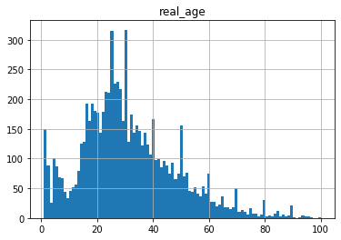

```python
labels.hist(bins=100)
```

```
array([[<matplotlib.axes._subplots.AxesSubplot object at 0x7f5201ed8410>]],
      dtype=object)
```

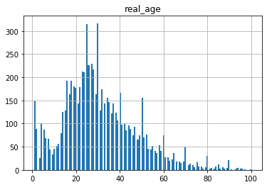

```python
labels.hist(bins=150)
```

We see that most of the photos are people from 20 to 40 years old.

```python
labels.describe()
```

|  | real_age |
| --- | --- |
| count | 7591.000000 |
| mean | 31.201159 |
| std | 17.145060 |
| min | 1.000000 |
| 25% | 20.000000 |
| 50% | 29.000000 |
| 75% | 41.000000 |
| max | 100.000000 |

Let's display some images:

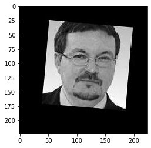

```python
img_batch = next(train_gen_flow)
batch_size=25

for i in range(batch_size):
    plt.imshow(img_batch[0][i])
```

### Conclusion:

There are 7591 photos in the dataset in total. Most of the photos are between 20 and 40 years old. There are very few photographs of elderly people, as well as children and adolescents, because of which the model may be undereducated.

## Model training.

```
from tensorflow.keras.applications.resnet import ResNet50
from tensorflow.keras.preprocessing.image import ImageDataGenerator
from tensorflow.keras.layers import GlobalAveragePooling2D, Dense
from tensorflow.keras.models import Sequential
from tensorflow.keras.optimizers import Adam
import numpy as np
import pandas as pd
import tensorflow as tf


def load_train(path):
    labels = pd.read_csv(path + 'labels.csv')
    datagen = ImageDataGenerator(validation_split=0.25, horizontal_flip=True, rescale=1./255)
    train_gen_flow = datagen.flow_from_dataframe(
        dataframe=labels,
        directory=path + 'final_files/',
        x_col='file_name',
        y_col='real_age',
        target_size=(224, 224),
        batch_size=16,
        class_mode='raw',
        subset='training',
        seed=12345)

    return train_gen_flow

def load_test(path):
    labels = pd.read_csv(path + 'labels.csv')
    datagen = ImageDataGenerator(validation_split=0.25, rescale=1./255)
    test_gen_flow = datagen.flow_from_dataframe(
        dataframe=labels,
        directory=path + 'final_files/',
        x_col='file_name',
        y_col='real_age',
        target_size=(224, 224),
        batch_size=16,
        class_mode='raw',
        subset='validation',
        seed=12345)

    return test_gen_flow


def create_model(input_shape):

    backbone = ResNet50(input_shape=input_shape,
                    weights='imagenet',
                    include_top=False)
    model = Sequential()
    model.add(backbone)
    model.add(GlobalAveragePooling2D())
    model.add(Dense(1, activation='relu'))

    optimizer = Adam(lr=0.0001)
    model.compile(optimizer=optimizer, loss='mean_squared_error',
                  metrics=['mae'])


    return model


def train_model(model, train_data, test_data, batch_size=None, epochs=10,
                steps_per_epoch=None, validation_steps=None):

    model.fit(train_data,
              validation_data=test_data,
              batch_size=batch_size,
              epochs=epochs,
              steps_per_epoch=steps_per_epoch,
              validation_steps=validation_steps,
              verbose=2)

    return model
```

```
Train for 356 steps, validate for 119 steps
Epoch 1/10
2021-04-10 00:45:31.594588: I tensorflow/stream_executor/platform/default/dso_loader.cc:44] Successfully opened dynamic library libcublas.so.10
2021-04-10 00:45:35.434860: I tensorflow/stream_executor/platform/default/dso_loader.cc:44] Successfully opened dynamic library libcudnn.so.7
356/356 - 116s - loss: 212.3699 - mae: 10.5944 - val_loss: 848.4941 - val_mae: 24.2711
Epoch 2/10
356/356 - 43s - loss: 83.5528 - mae: 6.9334 - val_loss: 219.1537 - val_mae: 11.2383
Epoch 3/10
356/356 - 44s - loss: 57.8109 - mae: 5.7618 - val_loss: 109.5048 - val_mae: 8.0670
Epoch 4/10
356/356 - 43s - loss: 44.2547 - mae: 5.1062 - val_loss: 69.5517 - val_mae: 6.3573
Epoch 5/10
356/356 - 43s - loss: 33.4268 - mae: 4.4318 - val_loss: 66.5731 - val_mae: 6.0704
Epoch 6/10
356/356 - 42s - loss: 23.7525 - mae: 3.7276 - val_loss: 68.2517 - val_mae: 6.1843
Epoch 7/10
356/356 - 42s - loss: 20.5827 - mae: 3.4592 - val_loss: 66.8859 - val_mae: 5.9757
Epoch 8/10
356/356 - 42s - loss: 16.1380 - mae: 3.0589 - val_loss: 71.2726 - val_mae: 6.2396
Epoch 9/10
356/356 - 42s - loss: 15.3093 - mae: 2.9988 - val_loss: 70.0582 - val_mae: 6.1250
Epoch 10/10
356/356 - 44s - loss: 12.8931 - mae: 2.7659 - val_loss: 64.5509 - val_mae: 5.8923

119/119 - 10s - loss: 64.5509 - mae: 5.8923
Test MAE: 5.8923
#
```

## Analysis of the trained model.

### Conclusion:

We built and trained a convolutional neural network using the ResNet50 architecture. During 10 epochs of training, we achieved a MAE of 2.76 on the training set, although it was 10 at the very beginning. In the end, we got a MAE of 5.89, which is a good enough result for a model that determines the age of customers. We trained the model in the GPU simulator, applied the ResNet50 architecture, used neural networks, which allowed us to increase the training speed and accuracy of the model.

The trained model allows you to predict the age of buyers with high accuracy. Obtaining a MAE value of 6 is a good indicator, since for categories of users an error of 6 years is not so terrible. Mainly due to the fact that the categories of buyers are divided by age by 8-12 years.

The use of GPU and neural networks allows you to quickly and efficiently process a large amount of information with high accuracy. This model allows us to solve the set tasks, especially for the offer of goods depending on the age group, but there may be problems in controlling the conscientiousness of cashiers when selling alcohol, since we do not have much data on people of childhood and adolescence, which may lead to an incorrect definition reaching the age of majority.